# Análisis Físico y Químico de Suelos en Colombia

Análisis Estadístico

Edimer David Jaramillo

[figure not shown]

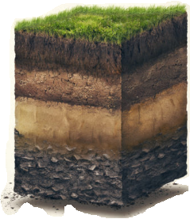

# Datos

- [Fuente de datos: *datos.gov.co*](https://www.datos.gov.co/Agricultura-y-Desarrollo-Rural/Resultados-de-An-lisis-de-Laboratorio-Suelos-en-Co/ch4u-f3i5)
- Datos descargados el 11 de febrero de 2020.

[figure not shown]

# Objetivos

- Explorar la situación actual de la composición química del suelo en Colombia.
- Evidenciar si existen diferencias entre regiones que sugieran cultivos de mayor potencial en determinadas zonas.
- Verificar qué tan homogéneas son las condiciones edáficas para cultivos que estén localizados en diferentes regiones.
- Implementar métodos de aprendizaje no supervisado (métodos estadísticos multivariados) que permitan hallar patrones de comportamiento subyacentes en los datos.

# Metodología

1. Importación de datos
2. Depuración, estructuración e integración de datos  
   2.1 Selección de variables de interés.  
   2.2 Unificación de mayúsuculas a minúsculas.  
   2.3 Unificación de niveles de factores (variables categóricas).  
   2.4 Eliminación de símbolos en variables numéricas.  
   2.5 Coerción de variables.  
   2.6 Edición de nombres de variables (no se tienen en cuenta tildes por viabilidad de análisis).  
   2.7 Filtrado de datos atípicos (errados) para variables químicas y físicas de suelo. Este filtro se aplicó basado en literatura y percentiles.
3. Información general
4. Análisis descriptivo  
   4.1 Deciles para cada variable numérica  
   4.2 Resumen numérico por departamento  
   4.3 Resumen numérico por municipio
5. Análisis exploratorio
6. Aprendizaje no supervisado
7. Referencias

# Resultados

## 1. Lectura de datos

```r
url <- "https://www.datos.gov.co/api/views/ch4u-f3i5/rows.csv?accessType=DOWNLOAD"
datos1 <- read.csv(file = url, encoding = "UTF-8")
```

## 2. Depuración, Estructuración e Integración

```r
library(Hmisc)
library(dplyr)
suppressWarnings(
  datos2 <- datos1 %>%
  # Punto 2.1
  select(-c(numfila, FechaAnalisis, Secuencial)) %>%
  # Punto 2.2
  mutate_at(c("Departamento", "Municipio", "Cultivo", "Estado",
              "Tiempo.Establecimiento", "Topografia", "Drenaje", "Riego",
              "Fertilizantes.aplicados"), as.character) %>%
  mutate_at(c("Departamento", "Municipio", "Cultivo", "Estado",
              "Tiempo.Establecimiento", "Topografia", "Drenaje", "Riego",
              "Fertilizantes.aplicados"), tolower) %>%
  mutate_at(c("Departamento", "Municipio", "Cultivo", "Estado",
              "Tiempo.Establecimiento", "Topografia", "Drenaje", "Riego",
              "Fertilizantes.aplicados"), capitalize) %>%
  # Punto 2.3
  mutate(Topografia = gsub("Error: #n/a", "Error", Topografia),
         Drenaje = gsub("Buen drenaje", "Bueno", Drenaje),
         Drenaje = gsub("Muy buen drenaje", "Bueno", Drenaje),
         Drenaje = gsub("Mal drenaje", "Malo", Drenaje),
         Drenaje = gsub("Regular drenaje", "Regular", Drenaje),
         Drenaje = gsub("Error: #n/a", "Error", Drenaje),
         Cultivo = gsub("Anon", "Anón", Cultivo),
         Cultivo = gsub("Aromaticas", "Aromáticas", Cultivo),
         Cultivo = gsub("cidron", "cidrón", Cultivo),
         Cultivo = gsub("oregano", "orégano", Cultivo),
         Cultivo = gsub("Arrayan", "Arrayán", Cultivo),
         Cultivo = gsub("Asai", "Asaí", Cultivo),
         Cultivo = gsub("Balu", "Balú", Cultivo),
         Cultivo = gsub("Brocoli", "Brócoli", Cultivo),
         Cultivo = gsub("Caña panelera/azucar", "Caña/azúcar", Cultivo),
         Cultivo = gsub("Caña/azucar", "Caña/azúcar", Cultivo),
         Cultivo = gsub("Citricos", "Cítricos", Cultivo),
         Cultivo = gsub("Epifitas ", "Epífitas ", Cultivo),
         Cultivo = gsub("arborea", "arbórea", Cultivo),
         Cultivo = gsub("Guanabana", "Guanábana", Cultivo),
         Cultivo = gsub("Mani", "Maní", Cultivo),
         Cultivo = gsub("Marañon", "Marañón", Cultivo),
         Cultivo = gsub("Rambutan", "Rambután", Cultivo),
         Cultivo = gsub("Saman", "Samán", Cultivo)) %>%
  # Punto 2.4
  mutate(pH.agua.suelo.2.5.1.0 = gsub("[< | >]", "", pH.agua.suelo.2.5.1.0),
         pH.agua.suelo.2.5.1.0 = gsub("[,]", ".", pH.agua.suelo.2.5.1.0),
         Fósforo..P..Bray.II.mg.kg = gsub("[< | >]", "",
                                          Fósforo..P..Bray.II.mg.kg),
         Fósforo..P..Bray.II.mg.kg = gsub("[,]", ".",
                                          Fósforo..P..Bray.II.mg.kg),
         Azufre..S..Fosfato.monocalcico.mg.kg = gsub("[< | >]", "",
                                          Azufre..S..Fosfato.monocalcico.mg.kg),
         Azufre..S..Fosfato.monocalcico.mg.kg = gsub("[,]", ".",
                                          Azufre..S..Fosfato.monocalcico.mg.kg),
         Acidez..Al.H..KCL.cmol....kg = gsub("[< | >]", "",
                                          Acidez..Al.H..KCL.cmol....kg),
         Acidez..Al.H..KCL.cmol....kg = gsub("[,]", ".",
                                          Acidez..Al.H..KCL.cmol....kg),
         Aluminio..Al..intercambiable.cmol....kg = gsub("[< | >]", "",
                                          Aluminio..Al..intercambiable.cmol....kg),
         Aluminio..Al..intercambiable.cmol....kg = gsub("[,]", ".",
                                          Aluminio..Al..intercambiable.cmol....kg),
         Calcio..Ca..intercambiable.cmol....kg = gsub("[< | >]", "",
                                          Calcio..Ca..intercambiable.cmol....kg),
         Calcio..Ca..intercambiable.cmol....kg = gsub("[,]", ".",
                                          Calcio..Ca..intercambiable.cmol....kg),
         Magnesio..Mg..intercambiable.cmol....kg = gsub("[< | >]", "",
                                          Magnesio..Mg..intercambiable.cmol....kg),
         Magnesio..Mg..intercambiable.cmol....kg = gsub("[,]", ".",
                                          Magnesio..Mg..intercambiable.cmol....kg),
         Potasio..K..intercambiable.cmol....kg = gsub("[< | >]", "",
                                          Potasio..K..intercambiable.cmol....kg),
         Potasio..K..intercambiable.cmol....kg = gsub("[,]", ".",
                                          Potasio..K..intercambiable.cmol....kg),
         Sodio..Na..intercambiable.cmol....kg = gsub("[< | >]", "",
                                          Sodio..Na..intercambiable.cmol....kg),
         Sodio..Na..intercambiable.cmol....kg = gsub("[,]", ".",
                                          Sodio..Na..intercambiable.cmol....kg),
         capacidad.de.intercambio.cationico..CICE..suma.de.bases.cmol....kg
         = gsub("[< | >]", "",
                capacidad.de.intercambio.cationico..CICE..suma.de.bases.cmol....kg),
         capacidad.de.intercambio.cationico..CICE..suma.de.bases.cmol....kg
         = gsub("[,]", ".",
                capacidad.de.intercambio.cationico..CICE..suma.de.bases.cmol....kg),
         Conductividad.el.ctrica..CE..relacion.2.5.1.0.dS.m
         = gsub("[< | >]", "",
                Conductividad.el.ctrica..CE..relacion.2.5.1.0.dS.m),
         Conductividad.el.ctrica..CE..relacion.2.5.1.0.dS.m
         = gsub("[,]", ".",
                Conductividad.el.ctrica..CE..relacion.2.5.1.0.dS.m),
         Hierro..Fe..disponible.olsen.mg.kg = gsub("[< | >]", "",
                                          Hierro..Fe..disponible.olsen.mg.kg),
         Hierro..Fe..disponible.olsen.mg.kg = gsub("[,]", ".",
                                          Hierro..Fe..disponible.olsen.mg.kg),
         Cobre..Cu..disponible.mg.kg = gsub("[< | >]", "",
                                          Cobre..Cu..disponible.mg.kg),
         Cobre..Cu..disponible.mg.kg = gsub("[,]", ".",
                                          Cobre..Cu..disponible.mg.kg),
         Manganeso..Mn..disponible.Olsen.mg.kg = gsub("[< | >]", "",
                                          Manganeso..Mn..disponible.Olsen.mg.kg),
         Manganeso..Mn..disponible.Olsen.mg.kg = gsub("[,]", ".",
                                          Manganeso..Mn..disponible.Olsen.mg.kg),
         Zinc..Zn..disponible.Olsen.mg.kg = gsub("[< | >]", "",
                                          Zinc..Zn..disponible.Olsen.mg.kg),
         Zinc..Zn..disponible.Olsen.mg.kg = gsub("[,]", ".",
                                          Zinc..Zn..disponible.Olsen.mg.kg),
         Boro..B..disponible.mg.kg = gsub("[< | >]", "",
                                          Boro..B..disponible.mg.kg),
         Boro..B..disponible.mg.kg = gsub("[,]", ".",
                                          Boro..B..disponible.mg.kg),
         Hierro..Fe..disponible.doble..cido.mg.kg = gsub("[< | >]", "",
                                          Hierro..Fe..disponible.doble..cido.mg.kg),
         Hierro..Fe..disponible.doble..cido.mg.kg = gsub("[,]", ".",
                                          Hierro..Fe..disponible.doble..cido.mg.kg),
         Cobre..Cu..disponible.doble.acido.mg.kg = gsub("[< | >]", "",
                                          Cobre..Cu..disponible.doble.acido.mg.kg),
         Cobre..Cu..disponible.doble.acido.mg.kg = gsub("[,]", ".",
                                          Cobre..Cu..disponible.doble.acido.mg.kg),
         Manganeso..Mn..disponible.doble.acido.mg.kg = gsub("[< | >]", "",
                                          Manganeso..Mn..disponible.doble.acido.mg.kg),
         Manganeso..Mn..disponible.doble.acido.mg.kg = gsub("[,]", ".",
                                          Manganeso..Mn..disponible.doble.acido.mg.kg),
         Zinc..Zn..disponible.doble..cido.mg.kg = gsub("[< | >]", "",
                                          Zinc..Zn..disponible.doble..cido.mg.kg),
         Zinc..Zn..disponible.doble..cido.mg.kg = gsub("[,]", ".",
                                          Zinc..Zn..disponible.doble..cido.mg.kg)) %>%
  # Punto 2.5
  mutate_at(c("Departamento", "Municipio", "Cultivo", "Estado",
              "Tiempo.Establecimiento", "Topografia", "Drenaje", "Riego",
              "Fertilizantes.aplicados"), as.factor) %>%
  mutate_if(is.character, as.numeric) %>%
  # Punto 2.6
  rename(tiempo_estab = Tiempo.Establecimiento,
         fertilizantes = Fertilizantes.aplicados,
         pH_agua_suelo = pH.agua.suelo.2.5.1.0,
         materia_org = Materia.orgánica..MO...,
         P_mg_kg = Fósforo..P..Bray.II.mg.kg,
         S_mg_kg = Azufre..S..Fosfato.monocalcico.mg.kg,
         acidez_cmol_kg = Acidez..Al.H..KCL.cmol....kg,
         Al_cmol_kg = Aluminio..Al..intercambiable.cmol....kg,
         Ca_cmol_kg = Calcio..Ca..intercambiable.cmol....kg,
         Mg_cmol_kg = Magnesio..Mg..intercambiable.cmol....kg,
         K_cmol_kg = Potasio..K..intercambiable.cmol....kg,
         Na_cmol_kg = Sodio..Na..intercambiable.cmol....kg,
         CICE = capacidad.de.intercambio.cationico..CICE..suma.de.bases.cmol....kg,
         conductividad = Conductividad.el.ctrica..CE..relacion.2.5.1.0.dS.m,
         Fe_olsen_mg_kg = Hierro..Fe..disponible.olsen.mg.kg,
         Cu_doble1_mg_kg = Cobre..Cu..disponible.mg.kg,
         Mn_olsen_mg_kg = Manganeso..Mn..disponible.Olsen.mg.kg,
         Zn_olsen_mg_kg = Zinc..Zn..disponible.Olsen.mg.kg,
         B_mg_kg = Boro..B..disponible.mg.kg,
         Fe_doble_mg_kg = Hierro..Fe..disponible.doble..cido.mg.kg,
         Cu_doble2_mg_kg = Cobre..Cu..disponible.doble.acido.mg.kg,
         Mn_doble_mg_kg = Manganeso..Mn..disponible.doble.acido.mg.kg,
         Zn_doble_mg_kg = Zinc..Zn..disponible.doble..cido.mg.kg) %>%
  # Punto 2.7
  filter(materia_org > 0) %>%
  filter(P_mg_kg <= 100) %>%
  filter(S_mg_kg <= 50) %>%
  filter(Fe_olsen_mg_kg <= 1000) %>%
  filter(Cu_doble1_mg_kg <= 10) %>%
  filter(Zn_olsen_mg_kg <= 20) %>%
  filter(B_mg_kg <= 20) %>%
  # Finalizando depuración
  select(-c(Zn_doble_mg_kg, Fe_doble_mg_kg, Cu_doble2_mg_kg, Mn_doble_mg_kg)) %>%
  droplevels()
)

datos2
```

| Departamento | Municipio | Cultivo | Estado | tiempo_estab | Topografia | Drenaje | Riego | fertilizantes | pH_agua_suelo | materia_org | P_mg_kg | S_mg_kg | acidez_cmol_kg | Al_cmol_kg | Ca_cmol_kg | Mg_cmol_kg | K_cmol_kg | Na_cmol_kg | CICE | conductividad | Fe_olsen_mg_kg | Cu_doble1_mg_kg | Mn_olsen_mg_kg | Zn_olsen_mg_kg | B_mg_kg |
| --- | --- | --- | --- | --- | --- | --- | --- | --- | --- | --- | --- | --- | --- | --- | --- | --- | --- | --- | --- | --- | --- | --- | --- | --- | --- |
| Cundinamarca | Funza | Uchuva | Por establecer | No aplica | Ondulado | Bueno | No indica | No indica | 5.66 | 9.7066792 | 5.622299 | 4.3455497 | NA | NA | 4.9656919 | 0.9788292 | 0.20453418 | 0.1459272 | 6.294983 | 0.2235132 | 184.118 | 1.000 | 2.876 | 3.462 | 0.10944206 |
| Cundinamarca | Villapinzón | Pastos-brachiaria | Establecido | No indica | Ondulado | Bueno | No cuenta con riego | No indica | 5.87 | 2.3366586 | 16.901172 | 14.4240838 | NA | NA | 9.5971831 | 0.9457007 | 0.19418087 | 0.1384634 | 10.875528 | 0.3344772 | 670.747 | 3.720 | 8.481 | 2.455 | 0.13090129 |
| Cundinamarca | Villapinzón | Pastos-brachiaria | Establecido | No indica | Ondulado | Bueno | No cuenta con riego | No indica | 5.56 | 6.8537572 | 32.076383 | 9.5811518 | NA | NA | 7.5283003 | 0.8416085 | 1.59041502 | 0.1400000 | 10.060324 | 0.3614256 | 791.175 | 6.830 | 5.694 | 2.631 | 0.30257511 |
| Meta | Acacías | Cítricos | Establecido | Mas de 10 años | Plano | Bueno | No cuenta con riego | No indica | 4.68 | 2.1194369 | 9.167087 | 15.2094241 | 2.83551764 | 2.52257713 | 1.7272163 | 0.4129294 | 0.15361164 | 0.1009529 | 5.230228 | 0.1431964 | 605.352 | 1.156 | 3.864 | 1.252 | 0.10944206 |
| Meta | Acacías | Aguacate | Establecido | Mas de 10 años | Plano | Regular | No cuenta con riego | Cal dolomita y calfos | 4.52 | 1.5091475 | 36.192439 | 10.1047120 | 2.70292149 | 2.51252702 | 1.2472144 | 0.2930876 | 0.07900027 | 0.1030581 | 4.425282 | 0.1310432 | 626.978 | 1.192 | 2.353 | 1.000 | 0.15236052 |
| Meta | Acacías | Cacao | Establecido | Mas de 10 años | Plano | Bueno | No cuenta con riego | 18-18-18 | 5.15 | 2.0987491 | 12.096665 | 5.2617801 | 1.23416415 | 1.00501081 | 1.6416899 | 0.4574628 | 0.11338002 | 0.1400000 | 3.546697 | 0.1616904 | 415.316 | 2.743 | 8.691 | 14.761 | 0.15236052 |
| Meta | Acacías | Cacao | Establecido | De 5 a 10 años | Plano | Bueno | No cuenta con riego | Calfos | 4.79 | 1.2221046 | 7.819482 | 3.2984293 | 1.38715971 | 1.11556200 | 2.0168423 | 0.3798009 | 0.09655589 | 0.1058331 | 3.986192 | 0.1173048 | 324.654 | 1.781 | 3.524 | 1.724 | 0.17381974 |
| Meta | Acacías | Cacao | Establecido | De 5 a 10 años | Pendiente | Regular | No cuenta con riego | 15-15-15 y cal dolomita | 5.04 | 0.7255979 | 3.893848 | 6.1780105 | 10.88308388 | 9.14559835 | 1.7575183 | 0.9924065 | 0.17685032 | 0.1541566 | 13.964016 | 0.0898280 | 67.511 | 1.927 | 17.209 | 4.300 | 0.17381974 |
| Meta | Acacías | Cacao | Establecido | De 5 a 10 años | Pendiente | Regular | No cuenta con riego | No indica | 5.14 | 0.5730256 | 3.864552 | 3.8219895 | 11.55626432 | 9.29634997 | 1.9230816 | 1.5362206 | 0.16790371 | 0.1111918 | 15.294662 | 0.0903564 | 52.258 | 1.859 | 17.108 | 6.059 | 0.10944206 |
| Meta | Acacías | Cacao | Establecido | De 5 a 10 años | Pendiente | Bueno | No cuenta con riego | 18-18-18 y cal dolomita | 4.78 | 0.7980051 | 7.336101 | 5.6544503 | 2.60092445 | 2.40197583 | 0.5500000 | 0.2673813 | 0.09768125 | 0.1400000 | 3.615987 | 0.0956404 | 335.027 | 1.000 | 3.927 | 1.000 | 0.21673820 |

[output cut: 990 more lines]

## 3. Información general

- Inicialmente la base de datos (sin depurar) contaba con 46745 filas, sin embargo, después de depurada se tienen 36765. El total de registros están distribuidos de la siguiente manera:
  - **Departamentos:** información de 31 departamentos.
  - **Municipios:** información de 893 municipios.
  - **Cultivos:** información de 215 culivos.
  - **Estado del cultivo:**
    - Establecido
    - Por establecer
    - No indica
  - **Tiempo de establecido el cultivo:**
    - 0 a 1 año
    - 1 a 5 años
    - 5 a 10 años
    - Más de 10 años
    - No aplica
    - No indica
  - **Topografía:**
    - Ligeramente ondulado
    - Moderadamente ondulado
    - Ondulado
    - Ondulado y pendiente
    - Pendiente
    - Pendiente fuerte
    - Pendiente leve
    - Pendiente moderada
    - Plano
    - Plano y ondulado
    - Plano y pendiente
    - No indica
    - Error. 212 registros presentan la categoría *“Error”* en esta variable.
  - **Drenaje:**
    - Bueno
    - Malo
    - Regular
    - No indica
    - Error. 21433 registros presentan la categoría *“Error”* en esta variable.
  - **Riego:**
    - Aspersión
    - Aspersión y goteo
    - Aspersión y gravedad
    - Cañón
    - Goteo
    - Goteo y gravedad
    - Gravedad
    - Manguera
    - Microaspersión
    - No cuenta con riego
    - Por inundación
    - No indica
  - **Fertilizantes:** información de 767 tipos de fertilización diferente.

## 4. Análisis descriptivo

### Deciles

```r
as.data.frame(datos2 %>%
  select_if(is.numeric) %>%
  apply(., 2,
        function(x){
          round(quantile(x, probs = seq(0.1, 1, 0.1), na.rm = TRUE), digits = 2)
          }))
```

|  | pH_agua_suelo | materia_org | P_mg_kg | S_mg_kg | acidez_cmol_kg | Al_cmol_kg | Ca_cmol_kg | Mg_cmol_kg | K_cmol_kg | Na_cmol_kg | CICE | conductividad | Fe_olsen_mg_kg | Cu_doble1_mg_kg | Mn_olsen_mg_kg | Zn_olsen_mg_kg | B_mg_kg |
| --- | --- | --- | --- | --- | --- | --- | --- | --- | --- | --- | --- | --- | --- | --- | --- | --- | --- |
| 10% | 4.71 | 1.18 | 3.64 | 2.45 | 0.32 | 0.12 | 0.68 | 0.22 | 0.09 | 0.04 | 2.80 | 0.10 | 23.60 | 1.00 | 1.10 | 1.00 | 0.07 |
| 20% | 4.95 | 1.62 | 3.87 | 3.29 | 0.57 | 0.35 | 1.27 | 0.37 | 0.11 | 0.08 | 3.90 | 0.13 | 47.58 | 1.00 | 1.80 | 1.00 | 0.11 |
| 30% | 5.15 | 2.04 | 3.87 | 4.04 | 0.85 | 0.58 | 2.06 | 0.57 | 0.14 | 0.12 | 4.92 | 0.16 | 70.40 | 1.33 | 2.50 | 1.00 | 0.13 |
| 40% | 5.34 | 2.48 | 5.26 | 4.86 | 1.16 | 0.84 | 3.10 | 0.83 | 0.18 | 0.14 | 6.05 | 0.19 | 91.20 | 1.70 | 3.28 | 1.02 | 0.16 |
| 50% | 5.55 | 3.03 | 7.23 | 5.80 | 1.54 | 1.16 | 4.35 | 1.19 | 0.23 | 0.14 | 7.43 | 0.22 | 133.81 | 2.10 | 4.20 | 1.40 | 0.19 |
| 60% | 5.77 | 3.80 | 10.49 | 6.98 | 1.95 | 1.53 | 5.92 | 1.65 | 0.29 | 0.14 | 9.19 | 0.26 | 195.57 | 2.60 | 5.34 | 1.84 | 0.22 |
| 70% | 6.03 | 4.96 | 16.01 | 8.62 | 2.46 | 1.98 | 7.82 | 2.28 | 0.37 | 0.14 | 11.58 | 0.31 | 275.77 | 3.20 | 6.90 | 2.48 | 0.27 |
| 80% | 6.38 | 7.08 | 25.95 | 11.34 | 3.15 | 2.61 | 10.48 | 3.35 | 0.50 | 0.18 | 15.34 | 0.40 | 390.01 | 4.10 | 9.28 | 3.50 | 0.32 |
| 90% | 6.91 | 11.30 | 45.49 | 16.73 | 4.43 | 3.73 | 15.23 | 5.87 | 0.73 | 0.27 | 21.70 | 0.59 | 582.04 | 5.60 | 14.40 | 5.70 | 0.44 |
| 100% | 9.67 | 58.64 | 99.88 | 49.93 | 28.31 | 25.81 | 103.81 | 29.88 | 6.30 | 10.67 | 111.01 | 20.63 | 1000.00 | 10.00 | 382.91 | 20.00 | 5.01 |

### Resumen numérico por departamento

- **n:** número de registros.
- **DE:** Desviación Estándar.
- **CV:** Coeficiente de Variación (%).

```r
library(DT)
library(tidyr)
datos2 %>%
  select(which(sapply(., class) == "numeric"), Departamento) %>%
  gather(key = "variable", value = "valor",-Departamento) %>%
  group_by(variable, Departamento) %>%
  summarise(
    n = n(),
    Promedio = round(mean(valor, na.rm = TRUE), digits = 2),
    Mediana = round(median(valor, na.rm = TRUE), digits = 2),
    Mínimo = round(min(valor, na.rm = TRUE), digits = 2),
    Máximo = round(max(valor, na.rm = TRUE), digits = 2),
    DE = round(sd(valor, na.rm = TRUE), digits = 2),
    Máximo = round(max(valor, na.rm = TRUE), digits = 2)
  ) %>%
  mutate(CV = round((DE / Promedio) * 100, digits = 2)) %>%
  rename(Variable = variable) %>%
  datatable()
```

|  | Variable | Departamento | n | Promedio | Mediana | Mínimo | Máximo | DE | CV |
| --- | --- | --- | --- | --- | --- | --- | --- | --- | --- |
| 1 | acidez_cmol_kg | Amazonas | 49 | 6.79 | 7.11 | 0.76 | 15.47 | 4.57 | 67.3 |
| 2 | acidez_cmol_kg | Antioquia | 2817 | 1.81 | 1.35 | 0 | 28.31 | 2.11 | 116.57 |
| 3 | acidez_cmol_kg | Arauca | 153 | 1.32 | 1.07 | 0.07 | 5.84 | 1.07 | 81.06 |
| 4 | acidez_cmol_kg | Atlántico | 300 | 1.34 | 0.37 | 0.08 | 8.77 | 2.31 | 172.39 |
| 5 | acidez_cmol_kg | Bogotá, d.c. | 13 | 2.44 | 1.99 | 1.02 | 6.25 | 1.67 | 68.44 |
| 6 | acidez_cmol_kg | Bolívar | 1268 | 1.86 | 0.59 | 0 | 13.08 | 2.36 | 126.88 |
| 7 | acidez_cmol_kg | Boyacá | 2057 | 2.54 | 2.18 | 0.07 | 13.97 | 1.85 | 72.83 |
| 8 | acidez_cmol_kg | Caldas | 318 | 1.14 | 0.92 | 0.1 | 6.85 | 0.84 | 73.68 |
| 9 | acidez_cmol_kg | Caquetá | 814 | 3.18 | 2.6 | 0.07 | 20.07 | 2.51 | 78.93 |
| 10 | acidez_cmol_kg | Casanare | 676 | 1.9 | 1.55 | 0.11 | 9.33 | 1.43 | 75.26 |

[output cut: 517 more lines]

### Resumen numérico por municipio

- **n:** número de registros.
- **DE:** Desviación Estándar.
- **CV:** Coeficiente de Variación (%).
- **Notas:**
  - se filtran municipios con 5 o más registros.
  - Se agrega la columna “Departamento” para saber a qué departamento corresponde el municipio.

```r
datos2 %>%
  select(which(sapply(., class) == "numeric"), Municipio, Departamento) %>%
  gather(key = "variable", value = "valor",-c(Municipio, Departamento)) %>%
  group_by(variable, Municipio, Departamento) %>%
  summarise(
    n = n(),
    Promedio = round(mean(valor, na.rm = TRUE), digits = 2),
    Mediana = round(median(valor, na.rm = TRUE), digits = 2),
    Mínimo = round(min(valor, na.rm = TRUE), digits = 2),
    Máximo = round(max(valor, na.rm = TRUE), digits = 2),
    DE = round(sd(valor, na.rm = TRUE), digits = 2),
    Máximo = round(max(valor, na.rm = TRUE), digits = 2)
  ) %>%
  ungroup() %>%
  filter(Promedio > 0 & DE > 0) %>%
  filter(n >= 5) %>%
  mutate(CV = round((DE / Promedio) * 100, digits = 2)) %>%
  rename(Variable = variable) %>%
  datatable()
```

|  | Variable | Municipio | Departamento | n | Promedio | Mediana | Mínimo | Máximo | DE | CV |
| --- | --- | --- | --- | --- | --- | --- | --- | --- | --- | --- |
| 1 | acidez_cmol_kg | Abejorral | Antioquia | 43 | 0.97 | 0.98 | 0.17 | 2.48 | 0.57 | 58.76 |
| 2 | acidez_cmol_kg | Abriaquí | Antioquia | 5 | 3.23 | 2.69 | 1.95 | 5.06 | 1.63 | 50.46 |
| 3 | acidez_cmol_kg | Acacías | Meta | 67 | 3.66 | 2.62 | 0.37 | 11.71 | 3.02 | 82.51 |
| 4 | acidez_cmol_kg | Acevedo | Huila | 9 | 2.97 | 2.54 | 0.16 | 6.85 | 2.17 | 73.06 |
| 5 | acidez_cmol_kg | Agrado | Huila | 37 | 4.4 | 5.94 | 0.12 | 8.91 | 3.98 | 90.45 |
| 6 | acidez_cmol_kg | Aguadas | Caldas | 17 | 0.9 | 0.5 | 0.32 | 2.6 | 0.87 | 96.67 |
| 7 | acidez_cmol_kg | Aguazul | Casanare | 94 | 1.65 | 1.35 | 0.11 | 7.29 | 1.27 | 76.97 |
| 8 | acidez_cmol_kg | Agustín codazzi | Cesar | 216 | 1.61 | 0.89 | 0 | 5.7 | 1.67 | 103.73 |
| 9 | acidez_cmol_kg | Albán | Cundinamarca | 17 | 1.64 | 1.02 | 0 | 5.5 | 1.66 | 101.22 |
| 10 | acidez_cmol_kg | Albania | Caquetá | 5 | 1.86 | 1.61 | 0.92 | 3.15 | 0.93 | 50 |

[output cut: 12220 more lines]

## 5. Análisis exploratorio

### pH vs Componentes del Suelo

#### Mango

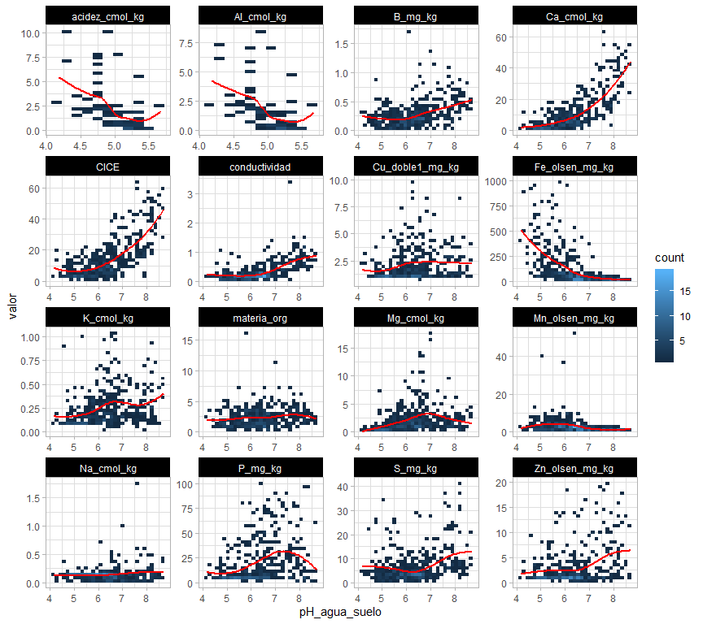

```r
datos2 %>%
  filter(Cultivo == "Mango") %>%
  select(which(sapply(., class) == "numeric"), Municipio, Departamento, Estado) %>%
  gather(key = "variable", value = "valor",-c(Municipio, Departamento, Estado,
                                              pH_agua_suelo)) %>%
  ggplot(data = ., aes(x = pH_agua_suelo, y = valor)) +
  facet_wrap(~variable, scales = "free") +
  geom_bin2d() +
  geom_smooth(se = FALSE, color = "red") +
  theme_light() +
  theme(strip.background = element_rect(fill = "black"))
```

#### P. Brachiaria

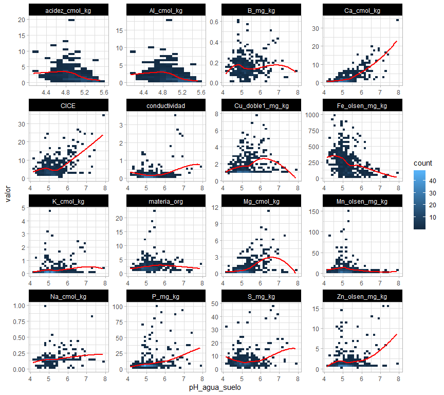

```r
datos2 %>%
  filter(Cultivo == "Pastos-brachiaria") %>%
  select(which(sapply(., class) == "numeric"), Municipio, Departamento, Estado) %>%
  gather(key = "variable", value = "valor",-c(Municipio, Departamento, Estado,
                                              pH_agua_suelo)) %>%
  ggplot(data = ., aes(x = pH_agua_suelo, y = valor)) +
  facet_wrap(~variable, scales = "free") +
  geom_bin2d() +
  geom_smooth(se = FALSE, color = "red") +
  theme_light() +
  theme(strip.background = element_rect(fill = "black"))
```

#### Limón

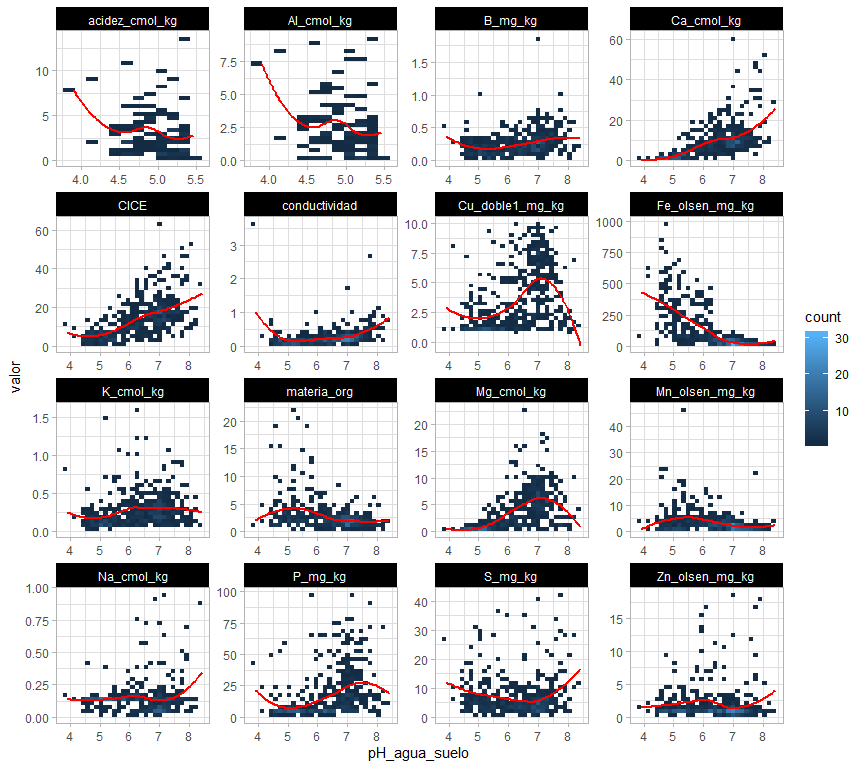

```r
datos2 %>%
  filter(Cultivo == "Cítricos-limón") %>%
  select(which(sapply(., class) == "numeric"), Municipio, Departamento, Estado) %>%
  gather(key = "variable", value = "valor",-c(Municipio, Departamento, Estado,
                                              pH_agua_suelo)) %>%
  ggplot(data = ., aes(x = pH_agua_suelo, y = valor)) +
  facet_wrap(~variable, scales = "free") +
  geom_bin2d() +
  geom_smooth(se = FALSE, color = "red") +
  theme_light() +
  theme(strip.background = element_rect(fill = "black"))
```

#### Uva

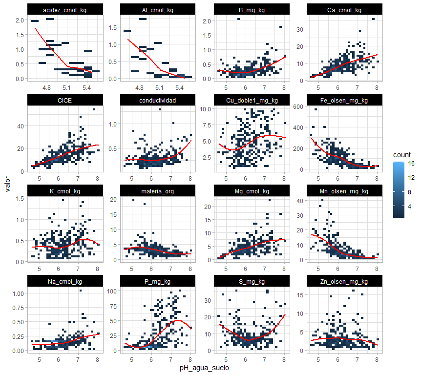

```r
datos2 %>%
  filter(Cultivo == "Uva") %>%
  select(which(sapply(., class) == "numeric"), Municipio, Departamento, Estado) %>%
  gather(key = "variable", value = "valor",-c(Municipio, Departamento, Estado,
                                              pH_agua_suelo)) %>%
  ggplot(data = ., aes(x = pH_agua_suelo, y = valor)) +
  facet_wrap(~variable, scales = "free") +
  geom_bin2d() +
  geom_smooth(se = FALSE, color = "red") +
  theme_light() +
  theme(strip.background = element_rect(fill = "black"))
```

#### Aguacate

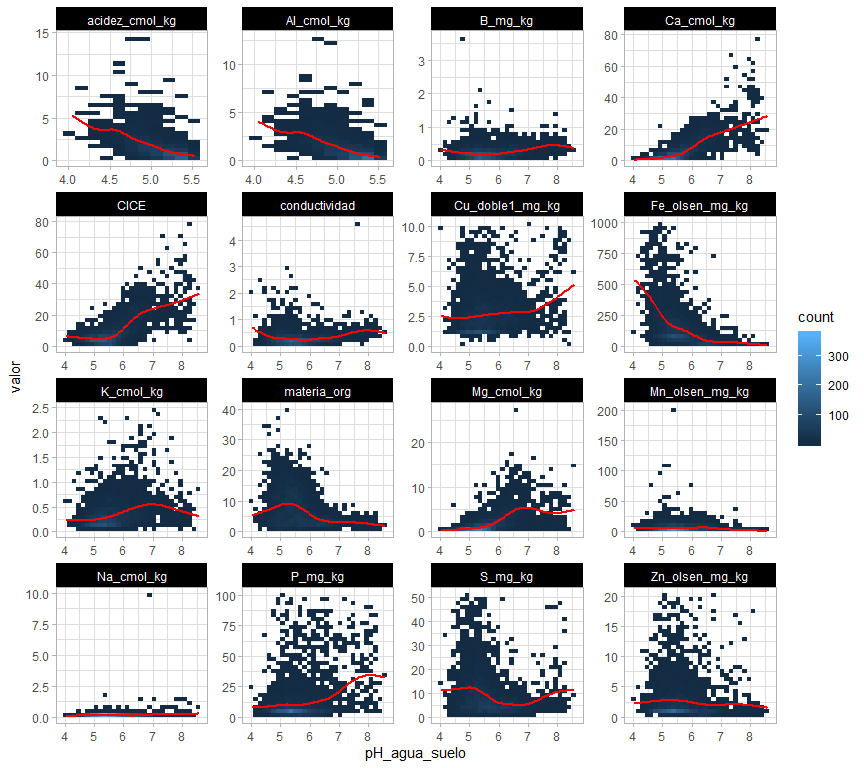

```r
datos2 %>%
  filter(Cultivo == "Aguacate") %>%
  select(which(sapply(., class) == "numeric"), Municipio, Departamento, Estado) %>%
  gather(key = "variable", value = "valor",-c(Municipio, Departamento, Estado,
                                              pH_agua_suelo)) %>%
  ggplot(data = ., aes(x = pH_agua_suelo, y = valor)) +
  facet_wrap(~variable, scales = "free") +
  geom_bin2d() +
  geom_smooth(se = FALSE, color = "red") +
  theme_light() +
  theme(strip.background = element_rect(fill = "black"))
```